# Quarto Notes

Learning Quarto

Author

Michael Helm

Published

October 9, 2024

Modified

October 9, 2024

Abstract

Here we will be going through tutorials/workshops of Quarto

# Questions

1. When would we use Yaml commands like:
- toi
- page-layout
- notebook-view
2. How do I get the photos to load in correctly? Uneven Columns Section
3. When you render a quarto document, how does it work, it just updates the same file?
4. Does ::: denote options in quarto?

# Quarto

- Similar to R-Markdown but more to it. Has more accessible defaults and supports better accessibility
- Different YAML will create 3 different outputs.
  - Document
    - title**:** “Lesson 1” format**:** html
  - Presentation
    - title**:** “Lesson 1” format**:** revealjs
  - Website
    - project**:** type**:** website

## Air Quality

Figure 1 further explores the impact of temperature on ozone level.

- To create the link above we used `@name` as well as these options within the R chunk
  - #| label: fig-airquality
  - #| fig-cap: Temperature and ozone level.
  - #| warning: false

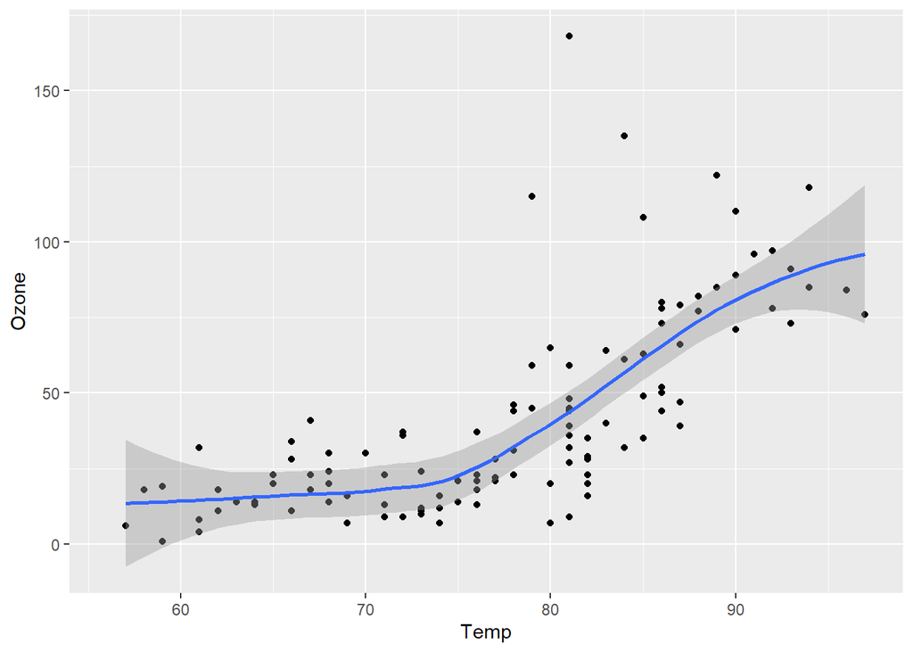

Figure 1: Temperature and ozone level.

```r
library(ggplot2)
ggplot(airquality,
       mapping = aes(x = Temp, y = Ozone)
       ) +

  geom_point() +
  geom_smooth(method = "loess"
)
```

```r
library(tidyverse)
library(palmerpenguins)
library(quarto)

penguins |>
  distinct(species)
```

```
# A tibble: 3 × 1
  species
  <fct>
1 Adelie
2 Gentoo
3 Chinstrap
```

## Text formatting

- *italics*, single star * before/after
- **bold**, double star ** before/after
- superscript<sup>2</sup> , base then ^ before/after exponent
- subscript<sub>2</sub>, base then ~ before/after subscript
- strikethrough, double tilda ~~ before/after
- `verbatim code`, code in r ’’

## Quarto Commands

### Uneven Columns

**Column 1**

- item 1
- item 2

**Column 2**

[figure not shown]

Practice Photo

## Callouts

**Note**

- There are five types of callouts: note, tip, warning, caution, and important.
- You can add headers to callouts same way you would normally would
- {.callout-note collapse=“true”} makes them collapsible

**Tip**

Here you go

**Caution**

caution!!

**Warning**

oh noooo

**Important**

make sure you see this

## Creating Tabs

**Tab 1**

This is Tab 1 using ::: panel-tabset

**Tab 2**

This is Tab 2

## Footnote Reference

Here is a footnote[^1]

<sup>1</sup> Here is one way to footnote

<sup>2</sup> Here is the other footnote.

and another[^2]

## In the Margins

Use `#| column: margin and output/code will be in margin like below

```r
mtcars[1:6, 1:3]
```

```
                   mpg cyl disp
Mazda RX4         21.0   6  160
Mazda RX4 Wag     21.0   6  160
Datsun 710        22.8   4  108
Hornet 4 Drive    21.4   6  258
Hornet Sportabout 18.7   8  360
Valiant           18.1   6  225
```